# Plan, Christian Romeo

[figure not shown]

#### Microloans are a lifeline for many Filipinos, providing essential capital to those traditionally underserved by banks. As digital platforms transform microlending with easier access to personal loans, the key to longevity lies in building a robust customer base despite the pressures of rising interest rates and diminishing profits. During my two-year tenure as Risk Analytics Manager for Lending at Mynt, I've been intimately involved in assessing the potential risks of business decisions, with a particular focus on customer reactions. We heavily rely on customer reviews and feedback as measurable indicators of our performance. These insights are not just metrics, they are foundational to the innovations and enhancements of our products and services.

# What are the factors influencing user satisfaction?

## Data Science Solution

#### With the rapid influx of customer feedback, these insights can become overwhelming and seem like mere noise if left untapped. However, when leveraged effectively, they become invaluable. Utilizing Machine Learning to perform Sentiment Analysis allows us to discern customer preferences and pinpoint their primary concerns. Harnessing this technology can guide our business strategy, steering our efforts in a direction that aligns with our customers' needs and experiences, thus fostering a more holistic approach to growth and improvement.

## Scope

#### The scope of my project will cover the use of text data to predict the rating and provide the key words and statements that drive this rating. It will focus on the available lending services in the Philippines and which to select.

## Value Creation

#### If we have all these reviews and we're able to maximize their use, we'll be able to **understand their feedbacks on a much deeper level** and we can **act on it through incorporating these insights to our Product Development Strategies**. We can go as far as offering **personalized responses as well as robust chatbots** which will eventually lead to **customer retention**

## Implication to me as a Data Scientist

#### The most obvious answer is **growth** but this is a huge step towards building the projects I'm genuinely interested in as I value the sentiments of my customers.

# Methodology

**Table 1. Methology Overview** are the steps I have taken to address the problem statement.

| Step | Process | Description |
| --- | --- | --- |
| 1 | Data Extraction and Cleaning | Upload the file and select the relevant columns and limit to just the lending app reviews. We will remove the stopwords at the start. |
| 2 | Exploratory Data Analysis | Perform EDA to gain understanding on the data and its characteristics, and identify any trends. |
| 3 | Data Vectorization | Represent text as vectors through bag-of-words representation with TF-IDF |
| 3 | Dimensionality Reductions | Reduce these vectorized data into the optimal number of Latent Factors |
| 4 | Model-building | Include baselines so we could compare the performance of our models. Select the best models and best parameters that will offer the most interpretable and most accurate results |
| 5 | Results | Utilize Precision, Recall, and Precision to determine accuracy of model |
| 6 | Insights and Recommendation | Summarize the insights from the generated results, and provide recommendations given the insights acquired |

# Data Description

## Data Scope & Limitations

**1. Lending Apps Only**  
The data covers all fintech apps including MAYA, BPI, BDO, METROBANK, ETC. which offer multiple services like bank transfers, savings accounts, and investments. This will project will be limited to the apps that offer personal loans only.  
This is due to the growing competitive space in lending as GCash has already reached Php50B and it has introduced [varying lending services](https://www.gcash.com/services/gloan) which proves the popularity of these services.  
**2. 15% of total dataset only**  
This is due to the dataset consisting of more than 1M rows which we logically limited to just 80K.

## Data Extraction & Cleaning

```python
# data mining and wrangling libraries
import pandas as pd
import numpy as np
from collections import Counter
import matplotlib.pyplot as plt
import re

# tokenization and stopwords
import nltk
from nltk.tokenize import word_tokenize
from nltk.corpus import stopwords

# Download necessary NLTK data
nltk.download('punkt')
nltk.download('stopwords')

# Settings the warnings to be ignored
import warnings
warnings.filterwarnings('ignore')
```

#### Assigned 3 as negative in reviews due to partial satisfaction with lending app services.

```python
!pip install kaggle
```

```
     ━━━━━━━━━━━━━━━━━━━━━━━━━━━━━━━━━━━━━━━━ 83.6/83.6 kB 2.5 MB/s eta 0:00:00
  Preparing metadata (setup.py) ... done
  WARNING: The script kaggle is installed in '/home/msds2024/cplan/.local/bin' which is not on PATH.
  Consider adding this directory to PATH or, if you prefer to suppress this warning, use --no-warn-script-location.
```

```python
# 1. Load data with specified datatypes and columns.
columns = ['review_text', 'review_rating', 'application_id']
dtypes = {'review_text': 'string', 'review_rating': 'int8', 'application_id': 'string'}
df = pd.read_csv('phbanks_app_reviews.csv', usecols=columns, dtype=dtypes).dropna()


# 2. Filter out non-lending specific financial service apps.
not_just_lending_apps = ['com.fronde.mbanking.android.pckg.bpi', 'com.citibank.CitibankPH', 'com.rcbc.mobilebanking', 'www.mobile.bdo.com.ph',
                         'com.landbank.mobilebanking','com.paymaya',  'com.unionbankph.online', 'com.tonik.mobile', 'com.securitybank.online',
                         'ph.com.bdo.retail', 'ph.seabank.seabank', 'com.cimbph.app2022', 'ph.uniondigital.superapp', 'ph.com.gotyme',
                         'com.iexceed.unoConsumerBanking', 'ph.com.metrobank.mcc.mbonline', 'com.bpi.ng.app'
                        ]
df = df[~df['application_id'].isin(not_just_lending_apps)]


# 3. Normalize review text.
def normalize_text(text): return re.sub(r'[^a-z0-9\s]', '', text.lower())
df['review_text'] = df['review_text'].apply(normalize_text).str.strip()

# Drop rows with empty review_text
lending_df['review_text'] = lending_df['review_text'].str.strip()


# 4. Remove stop words.
stop_words = stopwords.words('english') + ['ng', 'nang', 'ang', 'yung', 'yun', 'ung', 'po', 'na', 'sa', 'app', 'good', 'loan', 'tala', 'apps', 'ok', 'ko']
df['review_text'] = df['review_text'].apply(lambda x: ' '.join([word for word in word_tokenize(x) if word.lower() not in stop_words]))


# 5. Assign sentiment labels and remove empty reviews.
df['sentiment'] = df['review_rating'].apply(lambda x: 0 if x <= 3 else 1)
df = df[df['review_text'] != '']


# 6. Save the cleaned DataFrame.
pickle_filename = "lending_df.pkl"
df.to_pickle(pickle_filename)
```

```python
lending_df = pd.read_pickle("lending_df.pkl")
lending_df
```

|  | review_text | review_rating | application_id | sentiment |
| --- | --- | --- | --- | --- |
| 15383 | lets try | 5 | ph.com.tala | 1 |
| 15555 | sms confirmation code happen | 2 | ph.com.tala | 0 |
| 15946 | however always end error able complete transac... | 1 | ph.com.tala | 0 |
| 15983 | loading | 4 | ph.com.tala | 1 |
| 16187 | created vmoney account fully verified keep say... | 1 | ph.com.tala | 0 |
| ... | ... | ... | ... | ... |
| 1048557 | thankyou | 4 | com.luck.duck.quickla | 1 |
| 1048561 | chage review fair loaning | 3 | com.luck.duck.quickla | 0 |
| 1048566 | easy fill hope reponse | 5 | com.luck.duck.quickla | 1 |
| 1048568 | scam taas management fees 2700 lng nahiram 4k ... | 1 | com.mocamoca | 0 |
| 1048572 | hope approved niloan | 5 | ph.moneycat | 1 |

645926 rows × 4 columns

#### Limit to 15% of the total dataset while maintaining the distribution to avoid bias.

```python
sdf = lending_df.sample(frac=0.15, random_state=42)
sdf['review_rating'].value_counts()
```

```
review_rating
5    68987
1    17961
4     4772
3     3046
2     2123
Name: count, dtype: int64
```

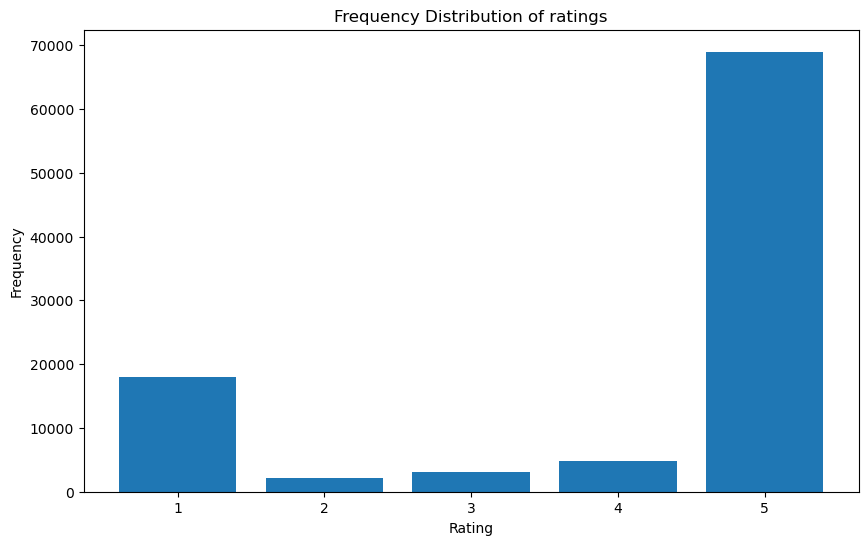

```python
# Validate the frequency
plt.figure(figsize=(10, 6))
plt.bar(list(Counter(sdf['review_rating']).keys()),
        list(Counter(sdf['review_rating']).values()))
plt.xlabel('Rating')
plt.ylabel('Frequency')
plt.title('Frequency Distribution of ratings')
plt.show()
```

#### Count words per document; cover top 80% of rows to prove concept.

```python
def split_text(text):
    return text.split()

sdf['review_length'] = sdf['review_text'].apply(lambda x: len(split_text(x)))
```

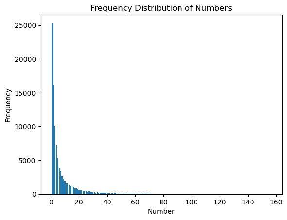

```python
# Calculate the frequency distribution
frequency_distribution = sdf['review_length'].value_counts().sort_index()

# Create a bar plot
plt.bar(frequency_distribution.index, frequency_distribution.values)

# Set labels and title
plt.xlabel('Number')
plt.ylabel('Frequency')
plt.title('Frequency Distribution of Numbers')

# Show the plot
plt.show()
```

```python
# Sort dataframe by review length in ascending order and select the top 80% of the reviews by length.
top_80 = sdf.sort_values('review_length').head(int(len(sdf) * 0.8))

# Filter the original dataframe to include only reviews within the length range of the top 80%.
filtered_sdf = sdf[sdf['review_length'].between(min(top_80['review_length']), max(top_80['review_length']))]
filtered_sdf.head(10)
```

|  | review_text | review_rating | application_id | sentiment | review_length |
| --- | --- | --- | --- | --- | --- |
| 107435 | emergency purposes | 5 | ph.com.tala | 1 | 2 |
| 851105 | approved yong tpus hindi nmn transfer gcashbki... | 1 | ph.com.tala | 0 | 9 |
| 235601 | love | 5 | ph.com.tala | 1 | 1 |
| 262724 | help lot way second | 5 | ph.com.tala | 1 | 4 |
| 698229 | nice easy satisfied late fees | 5 | com.mocamoca | 1 | 5 |
| 551719 | application fast hope disbursement | 4 | com.tmart.pesoq | 1 | 4 |
| 793197 | hb | 5 | ph.homecredit.myhomecredit | 1 | 1 |
| 437026 | nice | 5 | ph.homecredit.myhomecredit | 1 | 1 |
| 778155 | fast approval | 5 | com.abs.pesobuffet.android | 1 | 2 |
| 746265 | nice online lending well recommended | 5 | ph.com.tala | 1 | 5 |

#### filtered_sdf: Cleaned dataset for vectorization, dimensionality reduction, and ML training/testing.

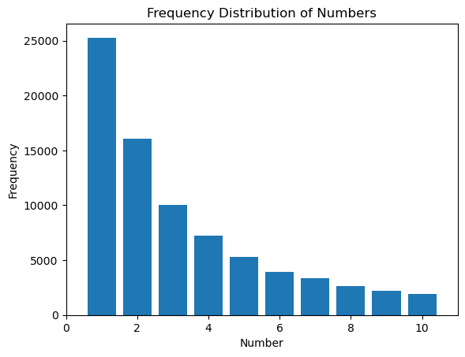

```python
# Calculate the frequency distribution
frequency_distribution = filtered_sdf['review_length'].value_counts().sort_index()

# Create a bar plot
plt.bar(frequency_distribution.index, frequency_distribution.values)

plt.xlim(0, max(top_80['review_length'])+1)  # Adjust the limits as needed

# Set labels and title
plt.xlabel('Number')
plt.ylabel('Frequency')
plt.title('Frequency Distribution of Numbers')

# Show the plot
plt.show()
```

```python
final_stopwords = stopwords.words('english')
final_stopwords.extend(['ng','nang','ang', 'yung', 'yun','ung', 'po', 'na', 'sa','app', 'good','loan', 'tala', 'apps', 'ok', 'ko'])

words = word_tokenize(" ".join(filtered_sdf['review_text']))
word_list = [word for word in words if word not in final_stopwords]
word_freq = Counter(word_list)
```

# Exploratory Data Analysis

#### Frequent words show class imbalance toward positive sentiments in loan services: fast approval, easy application, low interest rates.

[figure not shown]

```python
# Display top 30 frequent words
most_common_words = word_freq.most_common(30)

# Plotting the top 30 words
plt.figure(figsize=(10, 6))
plt.bar([word[0] for word in most_common_words], [word[1] for word in most_common_words])
plt.xlabel('Words')
plt.ylabel('Frequency')
plt.title('Top 30 Most Frequent Words in Reviews')
plt.xticks(rotation = 90)
plt.show()
```

```python
from wordcloud import WordCloud
```

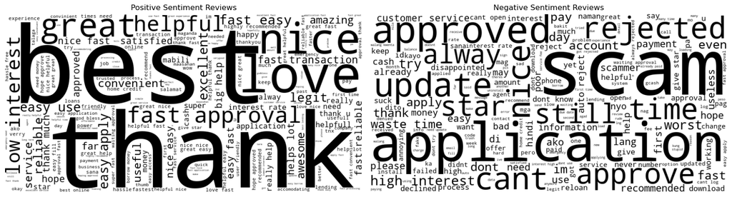

```python
from wordcloud import WordCloud
import matplotlib.pyplot as plt

# Function to make all words dark colored
def dark_color_func(word, font_size, position, orientation, random_state=None, **kwargs):
    return "hsl(0, 0%, 0%)"  # black color in HSL format

wordcloud_positive = WordCloud(width=800, height=400, background_color='white').generate(" ".join(filtered_sdf[filtered_sdf['sentiment']==1]['review_text']))
wordcloud_negative = WordCloud(width=800, height=400, background_color='white').generate(" ".join(filtered_sdf[filtered_sdf['sentiment']==0]['review_text']))

# Display the word clouds side by side
plt.figure(figsize=(16, 8))

# Positive word cloud
plt.subplot(1, 2, 1)
plt.imshow(wordcloud_positive.recolor(color_func=dark_color_func), interpolation='bilinear')
plt.title('Positive Sentiment Reviews')
plt.axis("off")

# Negative word cloud
plt.subplot(1, 2, 2)
plt.imshow(wordcloud_negative.recolor(color_func=dark_color_func), interpolation='bilinear')
plt.title('Negative Sentiment Reviews')
plt.axis("off")

plt.tight_layout()
plt.show()
```

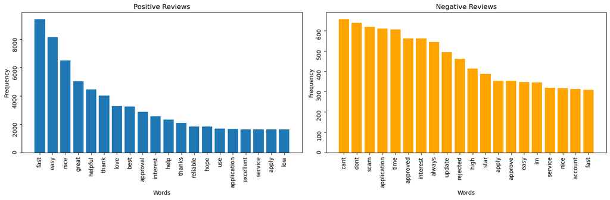

```python
from collections import Counter

# Placeholder data for positive and negative words, this will be replaced with actual data from filtered_sdf
positive_words = " ".join(filtered_sdf[filtered_sdf['sentiment'] == 1]['review_text']).split()
negative_words = " ".join(filtered_sdf[filtered_sdf['sentiment'] == 0]['review_text']).split()

# Count the frequency of each word
positive_word_freq = Counter(positive_words)
negative_word_freq = Counter(negative_words)

# Get the most common words for both positive and negative sentiments
top_positive_words = positive_word_freq.most_common(20)
top_negative_words = negative_word_freq.most_common(20)

# Create side-by-side bar plots
fig, axs = plt.subplots(1, 2, figsize=(15, 5))

# Positive word frequencies
axs[0].bar(*zip(*top_positive_words))
axs[0].set_title('Positive Reviews')
axs[0].tick_params(labelrotation=90)
axs[0].set_xlabel('Words')
axs[0].set_ylabel('Frequency')

# Negative word frequencies
axs[1].bar(*zip(*top_negative_words), color='orange')
axs[1].set_title('Negative Reviews')
axs[1].tick_params(labelrotation=90)
axs[1].set_xlabel('Words')
axs[1].set_ylabel('Frequency')

plt.tight_layout()
plt.show()
```

#### It seems like segregating by sentiment clearly shows the distinctions between a positive and negative sentiment. For the positive, we can see their key appreciations for the service: fast, easy, low interest, excellent service, etc. while negative can clearly show: can't apply, scammed, rejected with some noise given that it includes the rating 3.

# Data Vectorization: Term Frequency-Inverse Document Frequency (TFIDF)

#### TFIDF in loan app reviews clarifies positive (fast, easy) vs. negative (scammed, rejected) sentiments.

```python
from sklearn.feature_extraction.text import TfidfVectorizer
from sklearn.feature_extraction.text import CountVectorizer

# Initialize the TF-IDF Vectorizer
tfidf_vectorizer = TfidfVectorizer(max_features=3000, stop_words=final_stopwords)

# Fit and transform the 'review_text' column
tfidf_matrix = tfidf_vectorizer.fit_transform(filtered_sdf['review_text'])
```

```python
tfidf_matrix
```

```
<77939x3000 sparse matrix of type '<class 'numpy.float64'>'
	with 226206 stored elements in Compressed Sparse Row format>
```

# Dimensionality Reduction: Singlular Value Decomposition (SVD)

#### SVD simplifies loan app data, revealing key factors in user feedback for precise sentiment analysis.

[figure not shown]

```python
from sklearn.decomposition import TruncatedSVD

svd = TruncatedSVD(n_components=450)
X_svd = svd.fit_transform(tfidf_matrix)

# Plot the explained variance
plt.plot(svd.explained_variance_ratio_.cumsum())
plt.xlabel('Number of components')
plt.ylabel('Cumulative explained variance')
plt.show()
```

```python
optimal_n_components = next(i for i, cum_var in enumerate(svd.explained_variance_ratio_.cumsum()) if cum_var >= 0.8)
optimal_n_components
```

```
398
```

# Baseline: Proportion Chance Criteria ($P_{cc}$)

## Accuracy to beat is 79.40%

#### We use the whole dataset to run the $P_{CC}$

```
Population per class:        0
1  490903
0  155023
Proportion Chance Criterion: 63.52%
1.25 * Proportion Chance Criterion: 79.40%
```

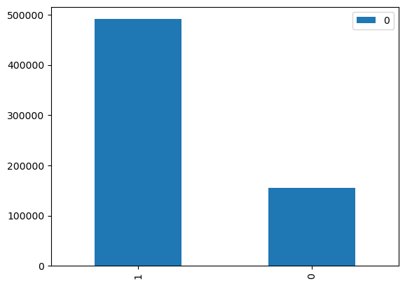

```python
from collections import Counter

lending_df = pd.read_pickle("lending_df.pkl")

counts = Counter(lending_df['sentiment'])
df_state = pd.DataFrame.from_dict(counts, orient='index')
df_state.plot(kind='bar')

num=(df_state[0]/df_state[0].sum())**2

print("Population per class:{}".format(df_state))
print("Proportion Chance Criterion: {:0.2f}%".format(100*num.sum()))
print("1.25 * Proportion Chance Criterion: {:0.2f}%".format(1.25*100*num.sum()))
```

# Machine Learning Pipeline

#### I created a pipeline the consists of TFIDF, SVD, and Logistic Regression

#### Conduct a train-test split

```python
from sklearn.model_selection import train_test_split
from sklearn.svm import SVC
from sklearn.metrics import accuracy_score, classification_report

X = filtered_sdf['review_text']
y = filtered_sdf['sentiment']

# Split data into training and testing sets
X_train, X_test, y_train, y_test = train_test_split(X, y, test_size=0.2, random_state=42)
```

# Best Parameter

#### Determine the best parameters for Logistic Regression using f1-score as basis

```python
from sklearn.model_selection import GridSearchCV

param_grid = {
    'logreg__C': [0.001, 0.01, 0.1, 1, 10, 100]  # Regularization values to try
}

grid_search = GridSearchCV(logreg_pipe, param_grid, cv=5, scoring='f1', verbose=1)
grid_search.fit(X_train, y_train)
print("Best parameter (C):", grid_search.best_params_)
```

[output not shown]

[output cut: 40 more lines]

[output not shown]

# Fit the model

#### Chose F1 score for balanced sentiment analysis in imbalanced datasets; captures genuine sentiments accurately.

```python
from sklearn.pipeline import Pipeline
from sklearn.feature_extraction.text import TfidfVectorizer
from sklearn.linear_model import LogisticRegression
from sklearn.decomposition import TruncatedSVD
from sklearn.metrics import classification_report

logreg_pipe = Pipeline([
    ('tfidf', TfidfVectorizer(max_features=3000, stop_words=final_stopwords)),
    ('svd', TruncatedSVD(n_components=350)),
    ('logreg', LogisticRegression(random_state=42, C=100, class_weight='balanced'))
], verbose=True)
```

```python
# Fit the pipeline to the training data
logreg_pipe.fit(X_train, y_train)

# Predictions on training data
y_train_pred = logreg_pipe.predict(X_train)

# Predictions on test data
y_test_pred = logreg_pipe.predict(X_test)

# Classification report for training data
print("Training Data Metrics:")
print(classification_report(y_train, y_train_pred))

# Classification report for test data
print("Test Data Metrics:")
print(classification_report(y_test, y_test_pred))
```

```
[Pipeline] ............. (step 1 of 3) Processing tfidf, total=   0.3s
[Pipeline] ............... (step 2 of 3) Processing svd, total=  12.2s
[Pipeline] ............ (step 3 of 3) Processing logreg, total=  27.5s
Training Data Metrics:
              precision    recall  f1-score   support

           0       0.52      0.85      0.64      9643
           1       0.97      0.85      0.91     52708

    accuracy                           0.85     62351
   macro avg       0.74      0.85      0.77     62351
weighted avg       0.90      0.85      0.87     62351

Test Data Metrics:
              precision    recall  f1-score   support

           0       0.50      0.84      0.62      2325
           1       0.97      0.85      0.91     13263

    accuracy                           0.85     15588
   macro avg       0.73      0.84      0.76     15588
weighted avg       0.90      0.85      0.86     15588
```

```python
from sklearn.model_selection import cross_val_score

# Assuming your pipeline is named 'pipeline' and it's already defined
# X and y are your features and labels
scores = cross_val_score(logreg_pipe, X, y, cv=5, scoring='f1')
print("Cross-validated scores:", scores)
```

```
[Pipeline] ............. (step 1 of 3) Processing tfidf, total=   0.3s
[Pipeline] ............... (step 2 of 3) Processing svd, total=  12.3s
[Pipeline] ............ (step 3 of 3) Processing logreg, total=  26.1s
[Pipeline] ............. (step 1 of 3) Processing tfidf, total=   0.3s
[Pipeline] ............... (step 2 of 3) Processing svd, total=  12.4s
[Pipeline] ............ (step 3 of 3) Processing logreg, total=  30.5s
[Pipeline] ............. (step 1 of 3) Processing tfidf, total=   0.3s
[Pipeline] ............... (step 2 of 3) Processing svd, total=  12.4s
[Pipeline] ............ (step 3 of 3) Processing logreg, total=  31.4s
[Pipeline] ............. (step 1 of 3) Processing tfidf, total=   0.4s
[Pipeline] ............... (step 2 of 3) Processing svd, total=  12.8s
[Pipeline] ............ (step 3 of 3) Processing logreg, total=  23.5s
[Pipeline] ............. (step 1 of 3) Processing tfidf, total=   0.3s
[Pipeline] ............... (step 2 of 3) Processing svd, total=  12.0s
[Pipeline] ............ (step 3 of 3) Processing logreg, total=  25.7s
Cross-validated scores: [0.9057499  0.90436187 0.9057182  0.90427764 0.90305606]
```

# Model Interpretation

#### svd_df now contains SVD components, their singular values, and corresponding logistic regression coefficients

```python
# 1. Access the SVD component and its singular values from the pipeline
svd = logreg_pipe.named_steps['svd']
singular_values = svd.singular_values_

# 2. Create a DataFrame to display SVD components and their singular values
svd_df = pd.DataFrame({
    'Component': range(1, len(singular_values) + 1),
    'Singular_Value': singular_values
})

# 3. Access the logistic regression model and its coefficients
logreg_model = logreg_pipe.named_steps['logreg']
flattened_coefficients = logreg_model.coef_.flatten()

# 4. Append the logistic regression coefficients to the SVD DataFrame
svd_df['LogReg_Coefficient'] = flattened_coefficients

svd_df
```

|  | Component | Singular_Value | LogReg_Coefficient |
| --- | --- | --- | --- |
| 0 | 1 | 60.024301 | 3.023563 |
| 1 | 2 | 51.421014 | 5.256587 |
| 2 | 3 | 48.507704 | 5.649009 |
| 3 | 4 | 42.770844 | 3.667980 |
| 4 | 5 | 37.798545 | 2.764132 |
| ... | ... | ... | ... |
| 345 | 346 | 4.703714 | -1.430630 |
| 346 | 347 | 4.699549 | -3.764565 |
| 347 | 348 | 4.674581 | -0.290193 |
| 348 | 349 | 4.671768 | -3.820208 |
| 349 | 350 | 4.662874 | 1.444937 |

350 rows × 3 columns

```python
top_3 = svd_df.sort_values(by='LogReg_Coefficient', ascending=False).head(3)
bot_3 = svd_df.sort_values(by='LogReg_Coefficient', ascending=False).tail(3)
```

```python
top_3
```

|  | Component | Singular_Value | LogReg_Coefficient |
| --- | --- | --- | --- |
| 183 | 184 | 6.701701 | 13.575263 |
| 279 | 280 | 5.355985 | 9.409838 |
| 188 | 189 | 6.628970 | 9.201671 |

# Top Latent Factors for the Positive Sentiments

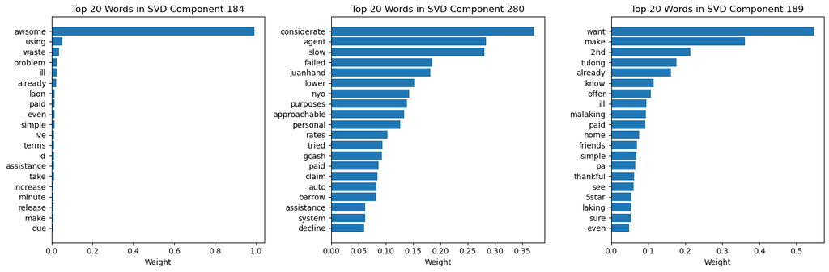

```python
import matplotlib.pyplot as plt

# Setup the plot - 3 subplots side by side
fig, axes = plt.subplots(1, 3, figsize=(15, 5))

# Iterate through each of the top 3 components
for i in [2,1,0]:
    component_num = top_3.iloc[i, 0]  # Assuming top_3 is a DataFrame
    selected_component = svd.components_[component_num]

    tfidf_vectorizer = logreg_pipe.named_steps['tfidf']
    feature_names = tfidf_vectorizer.get_feature_names_out()

    # Map each weight to its corresponding word
    word_weights = dict(zip(feature_names, selected_component))

    # Sort the words by their weights
    sorted_words = sorted(word_weights.items(), key=lambda x: x[1], reverse=True)

    # Number of top features to visualize
    top_n = 20

    # Split the words and their weights
    top_words, top_weights = zip(*sorted_words[:top_n])

    # Create bar plot on the ith subplot
    axes[i].barh(top_words, top_weights)
    axes[i].set_xlabel('Weight')
    axes[i].set_title(f'Top {top_n} Words in SVD Component {component_num}')
    axes[i].invert_yaxis()  # To display the highest value at the top

plt.tight_layout()
plt.show()
```

# Top Latent Factors for the Negative Sentiments

#### These words lean more towards challenges and dissatisfaction, with words like "fake," "rejected," and "hassle" appearing frequently. It suggests that users are often struggling with the app, feeling let down by its services, and are vocal about the difficulties they face, though there's a glimmer of hope that things might get better, as seen with words like "hopefully."

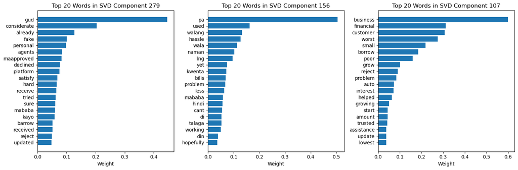

```python
import matplotlib.pyplot as plt

# Setup the plot - 3 subplots side by side
fig, axes = plt.subplots(1, 3, figsize=(15, 5))

# Iterate through each of the top 3 components
for i in [0,1,2]:
    component_num = bot_3.iloc[i, 0]  # Assuming top_3 is a DataFrame
    selected_component = svd.components_[component_num]

    tfidf_vectorizer = logreg_pipe.named_steps['tfidf']
    feature_names = tfidf_vectorizer.get_feature_names_out()

    # Map each weight to its corresponding word
    word_weights = dict(zip(feature_names, selected_component))

    # Sort the words by their weights
    sorted_words = sorted(word_weights.items(), key=lambda x: x[1], reverse=True)

    # Number of top features to visualize
    top_n = 20

    # Split the words and their weights
    top_words, top_weights = zip(*sorted_words[:top_n])

    # Create bar plot on the ith subplot
    axes[i].barh(top_words, top_weights)
    axes[i].set_xlabel('Weight')
    axes[i].set_title(f'Top {top_n} Words in SVD Component {component_num}')
    axes[i].invert_yaxis()  # To display the highest value at the top

plt.tight_layout()
plt.show()
```

# Conclusion & Recommendation

#### To finetune your sentiment analysis, tweak the TFIDF vectorizer by adjusting features and trialing n-grams to catch nuanced language patterns in customer feedback. Experiment with the number of dimensions in SVD for capturing variance more effectively and apply tools like topic modeling to interpret the decomposed components better. In optimizing the Logistic Regression model, a thorough grid search could refine crucial parameters, potentially enhancing model precision. Also, consider incorporating ensemble techniques like Random Forests or Gradient Boosting, which may be more adept at handling the complexities of sentiment data. Alongside the F1 score, the ROC-AUC score could offer deeper insights into your model's performance across various thresholds. Address class imbalance in your dataset head-on by employing techniques such as SMOTE, which can significantly improve model robustness by providing a more balanced training set. Post-modeling, tools like LIME or SHAP could shed light on your model's decision-making process, ensuring that the results remain transparent and interpretable. Maintain the model's sharpness by continuously benchmarking against fresh data, adapting to the latest linguistic and sentiment shifts.

# References

Kumari, K. "Sentiment Classification Using NLP with Text Analytics." Analytics Vidhya, 2021, analyticsvidhya.com/blog/2021/09/sentiment-classification-using-nlp-with-text-analytics/.

Luo, Xiaoyu. “Efficient English Text Classification Using Selected Machine Learning Techniques.” Alexandria Engineering Journal, vol. 60, no. 3, June 2021, pp. 3401–09. https://doi.org/10.1016/j.aej.2021.02.009.

Singh, D. "Text Classification of News Articles." Analytics Vidhya, 2022, www.analyticsvidhya.com/blog/2021/12/text-classification-of-news-articles/.

In the preparation of this work, I consulted ChatGPT, an AI language model developed by OpenAI, for insights and technical guidance on subjects including natural language processing, machine learning model optimization, sentiment analysis in microloan reviews, data visualization techniques, and effective strategies for handling imbalanced datasets in the context of text classification.